# Healthcare Data Challenge

```python
import numpy as np
import pandas as pd
import os
import copy
import math
import matplotlib.pyplot as plt
import seaborn as sns
import warnings
warnings.filterwarnings('ignore')
```

# Data Preprocessing

1. data type standardization
2. encode categorical variables
3. fill in missing values

```python
# read raw data
bill_amount = pd.read_csv('data/bill_amount.csv', header=0, dtype={'bill_id': str,
                                                                   'amount': float})
bill_id = pd.read_csv('data/bill_id.csv', header=0, dtype={'bill_id': str,
                                                           'patient_id': str,
                                                           'date_of_admission': str})

bill = bill_id.merge(bill_amount, on='bill_id', how='left')
bill = bill.groupby(['patient_id', 'date_of_admission'], as_index=False).amount.sum()

clinical_data = pd.read_csv('data/clinical_data.csv', header=0,
                            dtype={'id': str,
                                   'date_of_admission': str,
                                   'date_of_discharge': str,
                                   'weight': float,
                                   'height': float})
clinical_data.rename(columns={'id': 'patient_id'}, inplace=True)
dmgr = pd.read_csv('data/demographics.csv', header=0,
                   dtype={'patient_id': str,
                          'gender': str,
                          'race': str,
                          'resident_status': str,
                          'date_of_birth': str})

# explore
# print(bill_amount.describe())
# print(bill_id.dtypes)
# print(clinical_data.dtypes)  # inconsistent data types - require type standardization
# for col in clinical_data.columns[3:-2]:
#     print(col)
#     print(clinical_data[col].unique().tolist())
"""
recoding, dtype standardization, missing values
medical_history_2
[1.0, 0.0, nan]
medical_history_3
['0', 'No', '1', 'Yes']
medical_history_5
[0.0, nan, 1.0]
medical_history_2: missing values
medical_history_3: dtype, recode
medical_history_5: missing values
"""
# print(dmgr.dtypes)
# for col in dmgr.columns[1:4]:
#     print(col)
#     print(dmgr[col].unique().tolist())
"""
require recoding
gender
['Female', 'f', 'Male', 'm']
race
['Indian', 'Chinese', 'Malay', 'chinese', 'India', 'Others']
resident_status
['Singaporean', 'Singapore citizen', 'PR', 'Foreigner']

gender: recode
race: recode
residence_status: recode
"""
# preprocessing
# clinical data
# print(len(clinical_data))
# print(len(clinical_data[pd.isnull(clinical_data.medical_history_2)]))
# print(len(clinical_data[pd.isnull(clinical_data.medical_history_5)]))

clinical_data['medical_history_3'] = clinical_data['medical_history_3'].replace({'1': 1,
                                                                                 '0': 0,
                                                                                 'Yes': 1,
                                                                                 'No': 0})
# fill in missing using mode
clinical_data['medical_history_2'].fillna(clinical_data['medical_history_2'].mode()[0],
                                          inplace=True)
clinical_data['medical_history_5'].fillna(clinical_data['medical_history_2'].mode()[0],
                                          inplace=True)
# standardize data type
clinical_data.iloc[:, 3:21] = clinical_data.iloc[:, 3:21].astype(int)

# compute common clinical metrics
clinical_data['days_of_stay'] = clinical_data.apply(lambda x: (pd.to_datetime(
    x.date_of_discharge) - pd.to_datetime(x.date_of_admission)).days, axis=1)
clinical_data['bmi'] = clinical_data.weight / ((clinical_data.height / 100) ** 2)

# for col in clinical_data.columns[3:-2]:
#     print(col)
#     print(clinical_data[col].unique().tolist())

# demographic
# standardize categorical variables
dmgr.loc[:, 'gender'] = dmgr.loc[:, 'gender'].replace({'Female': 'f', 'Male': 'm'})
dmgr.loc[:, 'race'] = dmgr.loc[:, 'race'].replace({'Indian': 'in',
                                                   'Chinese': 'cn',
                                                   'Malay': 'my',
                                                   'chinese': 'cn',
                                                   'India': 'in',
                                                   'Others': 'other'})
dmgr.loc[:, 'resident_status'] = dmgr.loc[:, 'resident_status'].replace(
    {'Singaporean': 'ctz',
     'Singapore citizen': 'ctz',
     'PR': 'pr',
     'Foreigner': 'frn'})
# compute age from date of birth
dmgr['age'] = dmgr.apply(lambda x: (pd.datetime.today() - pd.to_datetime(
    x.date_of_birth)).days / 365.0, axis=1)
# print(dmgr.dtypes)
# for col in dmgr.columns[1:4]:
#     print(col)
#     print(dmgr[col].unique().tolist())

# check primary key
# if bill_id.groupby('bill_id', as_index=False).size().sort_values(ascending=False)[0] == 1:
#     print('no duplication')
# else:
#     print('duplication')
# if clinical_data.groupby(['patient_id', 'date_of_admission'], as_index=False).size(
#
# ).sort_values(ascending=False)[0] == 1:
#     print('no duplication')
# else:
#     print('duplication')
# if dmgr.groupby(['patient_id'], as_index=False).size().sort_values(
#         ascending=False)[0] == 1:
#     print('no duplication')
# else:
#     print('duplication')
```

```python
# create joined dataset
data = bill.merge(dmgr, on='patient_id', how='left')
data = data.merge(clinical_data, on=['patient_id', 'date_of_admission'], how='left')

data.to_csv('data/cost_of_care.txt', sep='|', header=True, index=False)
data_backup = copy.deepcopy(data)
```

```python
data.head()
```

|  | patient_id | date_of_admission | amount | gender | race | resident_status | date_of_birth | age | date_of_discharge | medical_history_1 | ... | symptom_3 | symptom_4 | symptom_5 | lab_result_1 | lab_result_2 | lab_result_3 | weight | height | days_of_stay | bmi |
| --- | --- | --- | --- | --- | --- | --- | --- | --- | --- | --- | --- | --- | --- | --- | --- | --- | --- | --- | --- | --- | --- |
| 0 | 00225710a878eff524a1d13be817e8e2 | 2014-04-10 | 5190.566695 | f | cn | ctz | 1983-01-16 | 37.189041 | 2014-04-22 | 0 | ... | 1 | 0 | 0 | 13.4 | 27.9 | 96.0 | 66.9 | 155.0 | 12 | 27.845994 |
| 1 | 0029d90eb654699c18001c17efb0f129 | 2012-11-07 | 22601.497872 | f | cn | ctz | 1943-10-14 | 76.473973 | 2012-11-20 | 0 | ... | 0 | 0 | 1 | 16.7 | 26.5 | 109.0 | 89.1 | 160.0 | 13 | 34.804687 |
| 2 | 0040333abd68527ecb53e1db9073f52e | 2013-01-19 | 17447.181635 | m | in | ctz | 1972-08-26 | 47.586301 | 2013-01-31 | 0 | ... | 0 | 0 | 1 | 14.8 | 25.2 | 96.0 | 79.5 | 172.0 | 12 | 26.872634 |
| 3 | 00473b58e3dc8ae37b3cb34069705083 | 2014-02-10 | 15285.883220 | f | cn | ctz | 1976-07-23 | 43.676712 | 2014-02-15 | 1 | ... | 1 | 1 | 0 | 14.9 | 28.7 | 122.0 | 81.1 | 160.0 | 5 | 31.679687 |
| 4 | 0078662d1d983dde68ea057c42d5b5cf | 2012-04-28 | 73477.869010 | m | my | frn | 1942-10-19 | 77.460274 | 2012-05-10 | 0 | ... | 0 | 1 | 1 | 14.2 | 27.2 | 89.0 | 74.7 | 173.0 | 12 | 24.959070 |

5 rows × 34 columns

# Exploratory Data Analysis

### Cost

From below descriptions statistics, the mean of cost is around $21859 with median $20180, which suggests a slightly right skewed dataset.

The average cost is much higher than $5407, the average hospital bill in Singapore (reference: TOSP hospital bill benchmark https://www.moh.gov.sg/cost-financing/fee-benchmarks-and-bill-amount-information). Based on TOSP hospital bill benchmarking, bills correspond to the majority of this sample (p25 to p75) are surgeries at private hospitals and unsubsidised public hospitals.

The skewness in accordance with the histogram and medical expenditure in reality. Extremely high medical bills could be due to expense medication, surgeries, intensive care units, etc.

```
count     3400.000000
mean     21859.071130
std      10155.336753
min       2946.100354
25%      14793.370831
50%      20180.020614
75%      26680.292435
max      98723.854994
Name: amount, dtype: float64
```

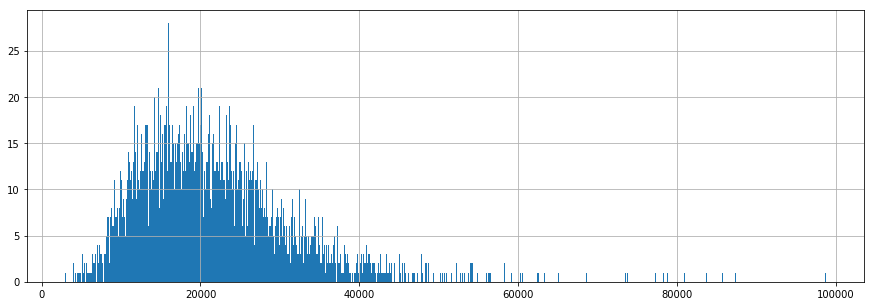

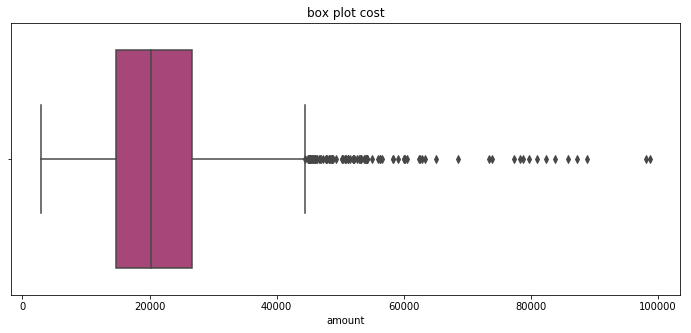

```python
# distribution of cost
print(data.amount.describe())
f= plt.figure(figsize=(15,5))
data.amount.hist(bins=1000)
plt.figure(figsize=(12,5))
plt.title('box plot cost')
sns.boxplot(x='amount', data=data , orient='h', palette = 'magma')
```

### Explore Correlation

Categorical variables are transformed using one-hot encoding. It can be observed that gender male and female has the same absolute correlation value, which implies the cost of care does not differ between female patients and male patients.

In terms of race, Malaysian has relatively higher correlation (0.386) than other races, followed by Indian (0.06). As the majority of Singapore population are Chinese, this factor may be confounding with residence status, which will be further validated. Indeed, foreigners show higher correlation (0.436) than other residence status, followed by permanent residence, which is in accordance with the bill policy in Singapore.

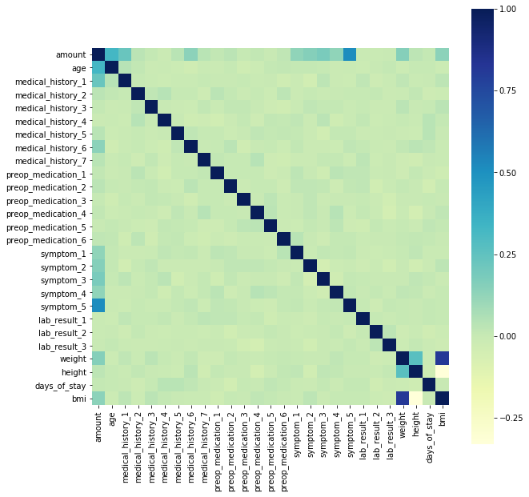

```python
f, ax = plt.subplots(figsize=(10, 10))
corr = data.corr()
sns.heatmap(corr, mask=np.zeros_like(corr, dtype=np.bool), cmap="YlGnBu",
            square=True, ax=ax)
```

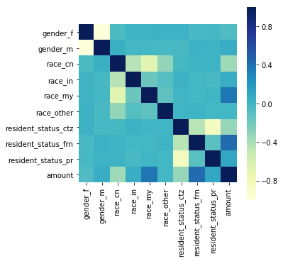

```python
# encode categorical variables
cols_to_encode = data.columns[3:6]
X1 = pd.get_dummies(data[cols_to_encode], drop_first=False)
X = pd.concat([X1, data['amount']], axis=1)
f, ax = plt.subplots(figsize=(5, 5))
corr = X.corr()
sns.heatmap(corr, mask=np.zeros_like(corr, dtype=np.bool), cmap="YlGnBu",
            square=True, ax=ax)
```

```python
# putting everything together
data_cor = pd.concat([X1, data['age'], data.iloc[:, 9:-2], data['amount']], axis=1)
corr_ = []
for i in data_cor.columns[:-1]:
    corr_.append([i, data_cor[[i,'amount']].corr()['amount'][i]])
pd.DataFrame(corr_).sort_values(by=1, ascending=False).reset_index(drop=True)
```

|  | 0 | 1 |
| --- | --- | --- |
| 0 | symptom_5 | 0.516790 |
| 1 | resident_status_frn | 0.435734 |
| 2 | race_my | 0.385877 |
| 3 | age | 0.325104 |
| 4 | medical_history_1 | 0.226518 |
| 5 | symptom_3 | 0.183988 |
| 6 | symptom_2 | 0.157819 |
| 7 | weight | 0.157511 |
| 8 | medical_history_6 | 0.141640 |
| 9 | symptom_4 | 0.130236 |
| 10 | symptom_1 | 0.128317 |
| 11 | resident_status_pr | 0.104483 |
| 12 | race_in | 0.060258 |
| 13 | gender_m | 0.057739 |
| 14 | medical_history_7 | 0.038951 |
| 15 | medical_history_5 | 0.036783 |
| 16 | medical_history_2 | 0.033585 |
| 17 | preop_medication_2 | 0.032263 |
| 18 | height | 0.026057 |
| 19 | preop_medication_6 | 0.021606 |
| 20 | preop_medication_1 | 0.016112 |
| 21 | preop_medication_4 | 0.015196 |
| 22 | medical_history_3 | 0.011539 |
| 23 | preop_medication_3 | 0.007839 |
| 24 | preop_medication_5 | 0.000453 |
| 25 | lab_result_3 | 0.000092 |
| 26 | lab_result_2 | -0.005537 |
| 27 | lab_result_1 | -0.006518 |
| 28 | medical_history_4 | -0.009356 |
| 29 | race_other | -0.012645 |
| 30 | gender_f | -0.057739 |
| 31 | resident_status_ctz | -0.325732 |
| 32 | race_cn | -0.357536 |

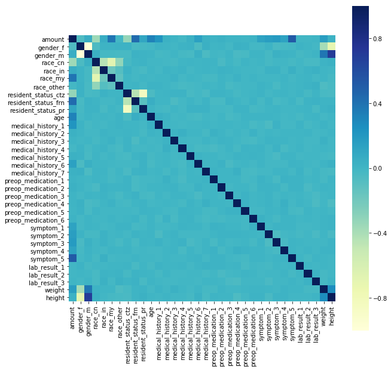

```python
# putting everything together
data_cor = pd.concat([data['amount'], X1, data['age'], data.iloc[:, 9:-2]], axis=1)
f, ax = plt.subplots(figsize=(10, 10))
corr_all = data_cor.corr()
sns.heatmap(corr_all, mask=np.zeros_like(corr_all, dtype=np.bool), cmap="YlGnBu",
            square=True, ax=ax)
```

## Age

Age feature displays bimodal distribution, which could imply there are two underlying population of patients in this sample whose average age has observable difference. This is further confirmed using KMeans clustering.

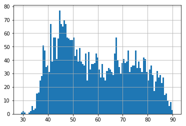

```python
data.age.hist(bins=100)
```

```
cluster
0    [[AxesSubplot(0.125,0.125;0.775x0.755)]]
1    [[AxesSubplot(0.125,0.125;0.775x0.755)]]
dtype: object
```

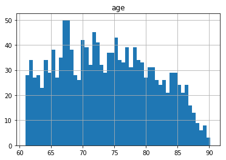

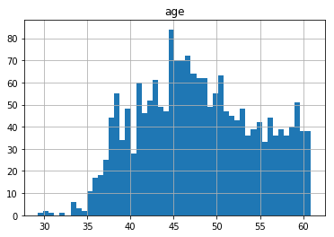

```python
from sklearn.cluster import KMeans
km = KMeans(n_clusters=2)
y_kmeans = km.fit_predict(data.age.values.reshape(-1,1))
age_profile = pd.DataFrame({'age': data.age, 'cluster': y_kmeans})
age_profile.groupby('cluster').hist(bins=50)
```

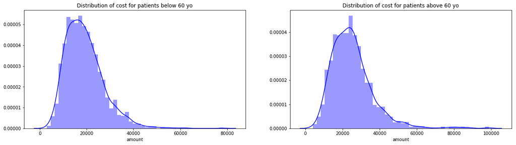

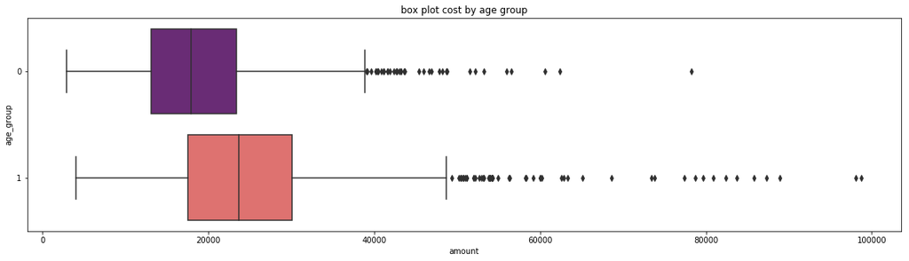

```python
f= plt.figure(figsize=(20,5))

ax=f.add_subplot(121)
sns.distplot(data[(data.age<60)]['amount'],color='b',ax=ax)
ax.set_title('Distribution of cost for patients below 60 yo')

ax=f.add_subplot(122)
sns.distplot(data[(data.age >= 60)]['amount'],color='b',ax=ax)
ax.set_title('Distribution of cost for patients above 60 yo')

plt.figure(figsize=(20,5))
plt.title('box plot cost by age group')
data_age = copy.deepcopy(data)
data_age['age_group'] = 0
data_age.loc[data_age.age >= 60, 'age_group'] = 1
sns.boxplot(y='age_group', x='amount', data=data_age , orient='h', palette = 'magma')
```

## Medical Histories

- Patients with medical history 1 and 6 on average have higher cost than those without.
- Patients with medical history 6 on average have higher cost than those without, but the difference is smaller than the medical history 1.

### medical history 1

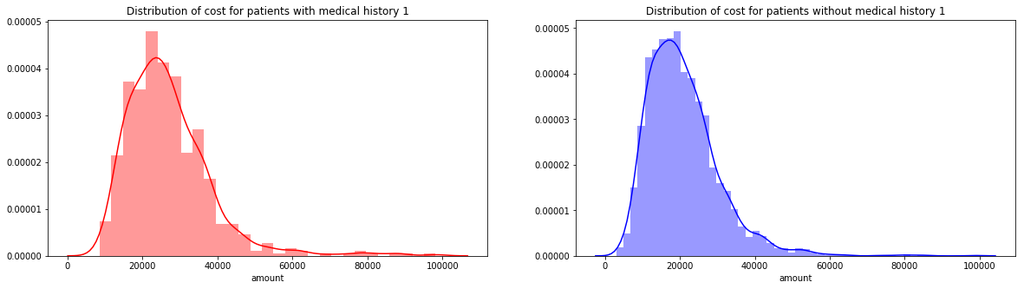

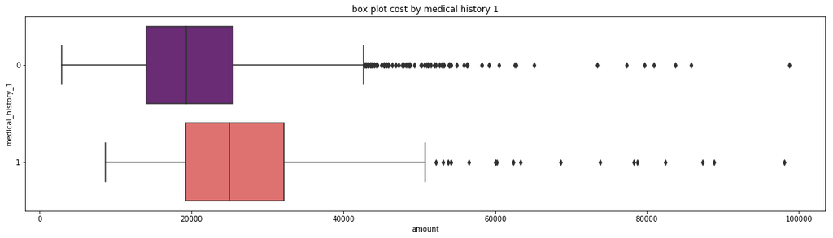

```python
f= plt.figure(figsize=(20,5))

ax=f.add_subplot(121)
sns.distplot(data[(data.medical_history_1 == 1)]['amount'],color='r',ax=ax)
ax.set_title('Distribution of cost for patients with medical history 1')

ax=f.add_subplot(122)
sns.distplot(data[(data.medical_history_1 == 0)]['amount'],color='b',ax=ax)
ax.set_title('Distribution of cost for patients without medical history 1')

plt.figure(figsize=(20,5))
plt.title('box plot cost by medical history 1')
sns.boxplot(y='medical_history_1', x='amount', data=data , orient='h', palette = 'magma')
```

### Medical History 6

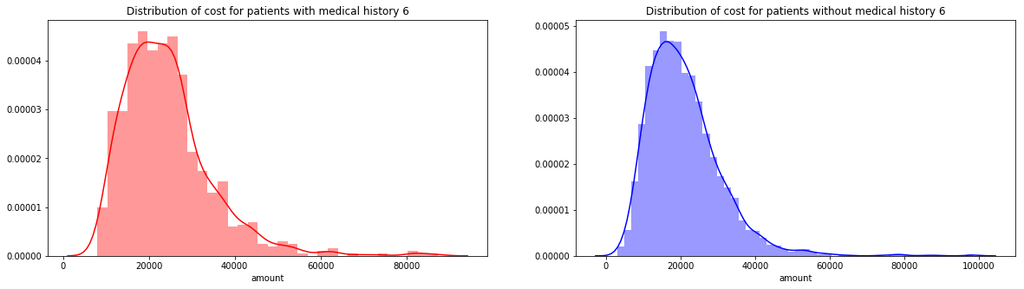

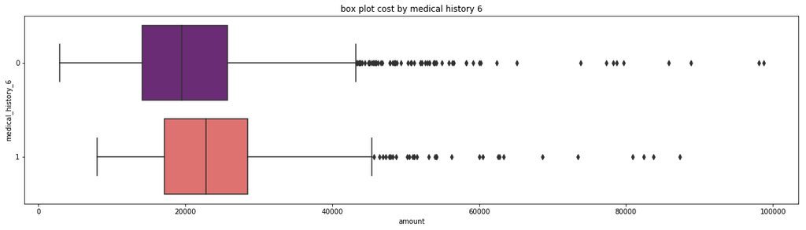

```python
f= plt.figure(figsize=(20,5))

ax=f.add_subplot(121)
sns.distplot(data[(data.medical_history_6 == 1)]['amount'],color='r',ax=ax)
ax.set_title('Distribution of cost for patients with medical history 6')

ax=f.add_subplot(122)
sns.distplot(data[(data.medical_history_6 == 0)]['amount'],color='b',ax=ax)
ax.set_title('Distribution of cost for patients without medical history 6')

plt.figure(figsize=(20,5))
plt.title('box plot cost by medical history 6')
sns.boxplot(y='medical_history_6', x='amount', data=data , orient='h', palette = 'magma')
```

## Symptoms

- Patients with symptoms on average have higher cost than those without, especially for symptom 5.
- For patients with symptom 5, 25% of cost is higher than 75% of those without.

Following patterns can be observed from the table in below section:

1. For symptom 1 to 4, as the number of symptoms increases, the average cost of care increases. This can be intepreted as when patients are diagnosed with one or more symptoms in the group of symptoms 1 to 4, the more symptoms a patients exhibits, the higher the cost of care tends to be, which could suggest that more symptoms imply higher severity and complexity of a certain type of disease.
2. The influence of symptoms on the increase of average cost follow the sequence of 4 < 1 < 2 < 3 < 5, which could suggest the severity of disease and complexity of treatment correspond to diagnosis from the symptoms.
3. Symptom 5 has larger influence on average cost than collective influence of symptoms 2 to 4, but smaller than the collective influence of symptom . This can be observed from the difference between mean cost of patients with only symptom 5 (18665.293012), patients with symptoms 2 to 4 (18441.017145), and patients with symptoms 1 to 4 (20788.698007).

Implication to model design: Introduce an engineered feature to represent sum of occurence for symtom 1 to 4.

### Symptom 1 as an example for symtom 1 to 4

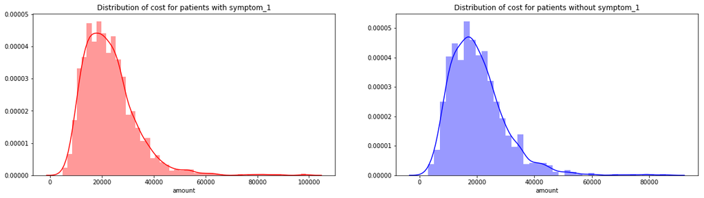

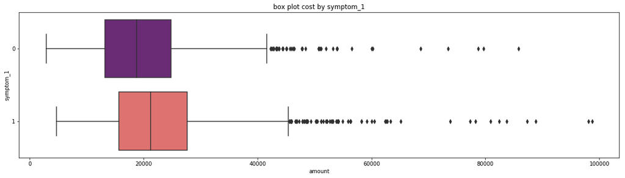

```python
f= plt.figure(figsize=(20,5))

ax=f.add_subplot(121)
sns.distplot(data[(data.symptom_1 == 1)]['amount'],color='r',ax=ax)
ax.set_title('Distribution of cost for patients with symptom_1')

ax=f.add_subplot(122)
sns.distplot(data[(data.symptom_1 == 0)]['amount'],color='b',ax=ax)
ax.set_title('Distribution of cost for patients without symptom_1')

plt.figure(figsize=(20,5))
plt.title('box plot cost by symptom_1')
sns.boxplot(y='symptom_1', x='amount', data=data , orient='h', palette = 'magma')
```

### Symptom 5

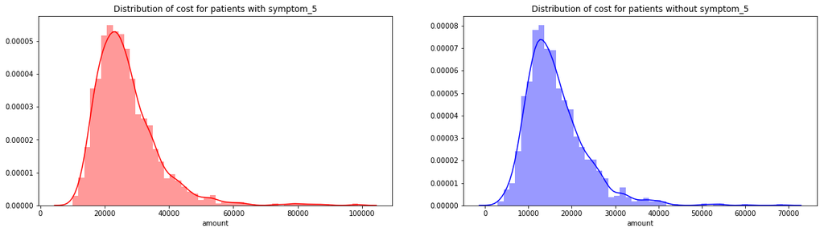

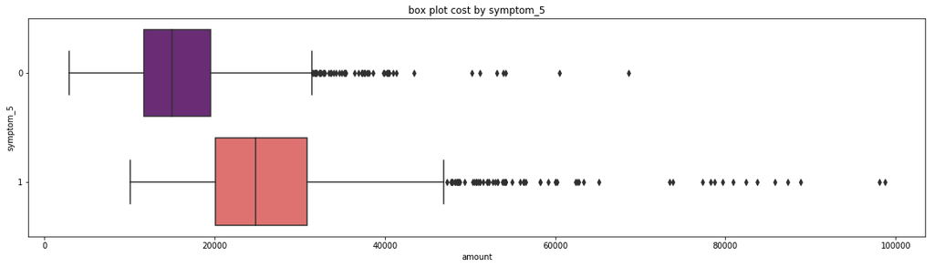

```python
f= plt.figure(figsize=(20,5))

ax=f.add_subplot(121)
sns.distplot(data[(data.symptom_5 == 1)]['amount'],color='r',ax=ax)
ax.set_title('Distribution of cost for patients with symptom_5')

ax=f.add_subplot(122)
sns.distplot(data[(data.symptom_5 == 0)]['amount'],color='b',ax=ax)
ax.set_title('Distribution of cost for patients without symptom_5')

plt.figure(figsize=(20,5))
plt.title('box plot cost by symptom_5')
sns.boxplot(y='symptom_5', x='amount', data=data , orient='h', palette = 'magma')
```

```python
data.groupby(['symptom_1', 'symptom_2', 'symptom_3',
              'symptom_4', 'symptom_5'], as_index=False).amount.mean().sort_values(by='amount')
```

|  | symptom_1 | symptom_2 | symptom_3 | symptom_4 | symptom_5 | amount |
| --- | --- | --- | --- | --- | --- | --- |
| 0 | 0 | 0 | 0 | 0 | 0 | 7477.144841 |
| 2 | 0 | 0 | 0 | 1 | 0 | 11125.033912 |
| 16 | 1 | 0 | 0 | 0 | 0 | 11142.964366 |
| 8 | 0 | 1 | 0 | 0 | 0 | 11472.253122 |
| 4 | 0 | 0 | 1 | 0 | 0 | 12056.785573 |
| 18 | 1 | 0 | 0 | 1 | 0 | 14072.651009 |
| 24 | 1 | 1 | 0 | 0 | 0 | 14440.360427 |
| 20 | 1 | 0 | 1 | 0 | 0 | 14635.249814 |
| 10 | 0 | 1 | 0 | 1 | 0 | 15349.265161 |
| 12 | 0 | 1 | 1 | 0 | 0 | 15858.324287 |
| 6 | 0 | 0 | 1 | 1 | 0 | 16430.023063 |
| 22 | 1 | 0 | 1 | 1 | 0 | 16531.566120 |
| 28 | 1 | 1 | 1 | 0 | 0 | 16628.756878 |
| 26 | 1 | 1 | 0 | 1 | 0 | 17884.478309 |
| 14 | 0 | 1 | 1 | 1 | 0 | 18441.017145 |
| 1 | 0 | 0 | 0 | 0 | 1 | 18665.293012 |
| 17 | 1 | 0 | 0 | 0 | 1 | 19650.333473 |
| 3 | 0 | 0 | 0 | 1 | 1 | 20458.712959 |
| 9 | 0 | 1 | 0 | 0 | 1 | 20591.903092 |
| 30 | 1 | 1 | 1 | 1 | 0 | 20788.698007 |
| 5 | 0 | 0 | 1 | 0 | 1 | 22027.130802 |
| 19 | 1 | 0 | 0 | 1 | 1 | 23746.989376 |
| 25 | 1 | 1 | 0 | 0 | 1 | 24464.754145 |
| 21 | 1 | 0 | 1 | 0 | 1 | 25291.653416 |
| 7 | 0 | 0 | 1 | 1 | 1 | 25385.994059 |
| 11 | 0 | 1 | 0 | 1 | 1 | 25616.972210 |
| 13 | 0 | 1 | 1 | 0 | 1 | 27206.902715 |
| 27 | 1 | 1 | 0 | 1 | 1 | 27521.893883 |
| 15 | 0 | 1 | 1 | 1 | 1 | 28379.359118 |
| 23 | 1 | 0 | 1 | 1 | 1 | 28497.744720 |
| 29 | 1 | 1 | 1 | 0 | 1 | 30698.923568 |
| 31 | 1 | 1 | 1 | 1 | 1 | 31267.764273 |

### Resident Status

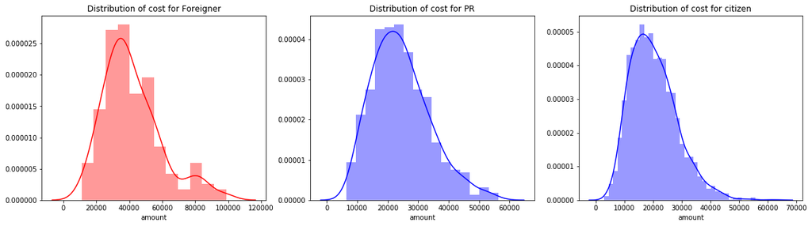

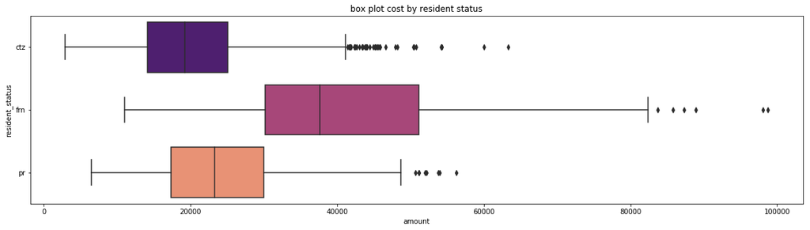

```python
f= plt.figure(figsize=(20,5))

ax=f.add_subplot(131)
sns.distplot(data[(data.resident_status == 'frn')]['amount'],color='r',ax=ax)
ax.set_title('Distribution of cost for Foreigner')

ax=f.add_subplot(132)
sns.distplot(data[(data.resident_status == 'pr')]['amount'],color='b',ax=ax)
ax.set_title('Distribution of cost for PR')

ax=f.add_subplot(133)
sns.distplot(data[(data.resident_status == 'ctz')]['amount'],color='b',ax=ax)
ax.set_title('Distribution of cost for citizen')


plt.figure(figsize=(20,5))
plt.title('box plot cost by resident status')
sns.boxplot(y='resident_status', x='amount', data=data , orient='h', palette = 'magma')
```

### Race

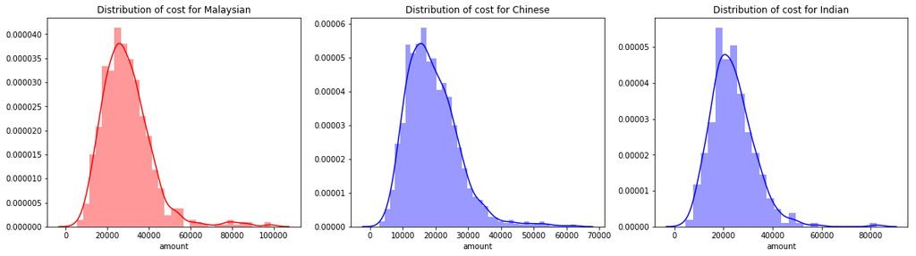

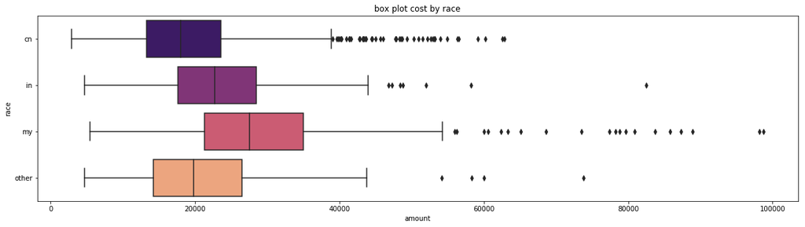

```python
f= plt.figure(figsize=(20,5))

ax=f.add_subplot(131)
sns.distplot(data[(data.race == 'my')]['amount'],color='r',ax=ax)
ax.set_title('Distribution of cost for Malaysian')

ax=f.add_subplot(132)
sns.distplot(data[(data.race == 'cn')]['amount'],color='b',ax=ax)
ax.set_title('Distribution of cost for Chinese')

ax=f.add_subplot(133)
sns.distplot(data[(data.race == 'in')]['amount'],color='b',ax=ax)
ax.set_title('Distribution of cost for Indian')


plt.figure(figsize=(20,5))
plt.title('box plot cost by race')
sns.boxplot(y='race', x='amount', data=data , orient='h', palette = 'magma')
```

# Feature Engineering

```python
data['no_of_symptoms'] = data[[
    'symptom_1',
    'symptom_2',
    'symptom_3',
    'symptom_4']].sum(axis=1)
data[['no_of_symptoms','amount']].corr()
```

|  | no_of_symptoms | amount |
| --- | --- | --- |
| no_of_symptoms | 1.000000 | 0.306429 |
| amount | 0.306429 | 1.000000 |

```python
data['no_of_med_history'] = data[[
    'medical_history_1',
    'medical_history_6']].sum(axis=1)
data[['no_of_med_history','amount']].corr()
```

|  | no_of_med_history | amount |
| --- | --- | --- |
| no_of_med_history | 1.000000 | 0.255893 |
| amount | 0.255893 | 1.000000 |

```python
# one-hot encoding
cols_to_encode = data.columns[3:6]
X1 = pd.get_dummies(data[cols_to_encode], drop_first=False)
X2 = data['age']
X3 = data.iloc[:, 9:]
X = pd.concat([X1, X2, X3], axis=1)
y = data['amount']
```

# Model Exploration

Following models are selected for benchmarking performance using cross validation. Since the prediction target is continuous, regression methods are used and score computed as coefficient of determination R^2 of the prediction.

Grid search is used to optimize hyperparameters.

1. Linear Regression
2. Decision Tree
3. Support Vector Machine Regression
4. Random Forest
5. Stochastic Gradient Descent Regressor
6. Keras Neural Network

```python
from sklearn import metrics
from sklearn.model_selection import train_test_split, GridSearchCV, cross_val_score
from sklearn.decomposition import PCA
from sklearn.preprocessing import MinMaxScaler, StandardScaler, PowerTransformer
from sklearn.tree import DecisionTreeRegressor
from sklearn.svm import SVR
from sklearn.linear_model import LinearRegression, SGDRegressor
from sklearn.ensemble import RandomForestRegressor
from sklearn.metrics import mean_squared_error
```

### Linear Regression

Linear regression is the simpliest model to start with and despite its simplicity, many times could yield good result.

```python
scaler = MinMaxScaler()
X_trans = scaler.fit_transform(X)

lr = LinearRegression() # no grid search required
print('cv r2: {:.3f}'.format(np.mean(cross_val_score(lr, X_trans, y, cv=10, scoring='r2'))))
print('cv mse: {:.3f}'.format(np.mean(cross_val_score(lr, X_trans, y, cv=10, scoring='neg_mean_squared_error'))))
```

```
cv r2: 0.926
cv mse: -7699212.553
```

```python
scaler = MinMaxScaler()
pt = PowerTransformer()

X_trans = scaler.fit_transform(X)
X_trans = pt.fit_transform(X_trans)

y_trans = pt.fit_transform(y.values.reshape(-1,1))

X_train, X_test, y_train, y_test = train_test_split(X_trans, y_trans, test_size=0.20, random_state=99)

# R2
lr = LinearRegression()
print('linear regression cv score: {:.3f}'.format(np.mean(cross_val_score(lr, X_trans, y_trans, cv=10))))

# MSE
lr.fit(X_train, y_train)
y_pred = lr.predict(X_test)
y_pred = pt.inverse_transform(y_pred.reshape(-1,1)).flatten().tolist()
y_test = pt.inverse_transform(y_test).flatten().tolist()

mse = mean_squared_error(y_pred, y_test)
print('cv mse: {:.3f}'.format(mse))
```

```
linear regression cv score: 0.981
cv mse: 1484305.260
```

### Decision Tree Regressor

```python
# grid search
dtr = DecisionTreeRegressor(random_state=99, min_samples_leaf=10)
parameters = {'criterion': ['mse', 'friedman_mse', 'mae'],
              'splitter': ['best', 'random'],
              'ccp_alpha': [0, 0.05, 0.1]}

gs_dtr = GridSearchCV(dtr, parameters, return_train_score=True, cv=10)
gs_dtr.fit(X, y) # feature scaling not required
result_cols = ['mean_test_score','mean_train_score', 'params', 'rank_test_score']
gs_result = pd.DataFrame(gs_dtr.cv_results_)[result_cols].sort_values(by='rank_test_score').reset_index(drop=True)
gs_result.head()
```

|  | mean_test_score | mean_train_score | params | rank_test_score |
| --- | --- | --- | --- | --- |
| 0 | 0.860574 | 0.919529 | {'ccp_alpha': 0, 'criterion': 'mse', 'splitter... | 1 |
| 1 | 0.860574 | 0.919529 | {'ccp_alpha': 0.1, 'criterion': 'friedman_mse'... | 1 |
| 2 | 0.860574 | 0.919529 | {'ccp_alpha': 0.1, 'criterion': 'mse', 'splitt... | 1 |
| 3 | 0.860574 | 0.919529 | {'ccp_alpha': 0.05, 'criterion': 'mse', 'split... | 1 |
| 4 | 0.860574 | 0.919529 | {'ccp_alpha': 0.05, 'criterion': 'friedman_mse... | 1 |

```python
# cross validation using optmized parameters
dtr = DecisionTreeRegressor(random_state=99, min_samples_leaf=10, criterion='mse', splitter='best', ccp_alpha=0)

print('cv r2: {:.3f}'.format(np.mean(cross_val_score(dtr, X_trans, y, cv=10, scoring='r2'))))
print('cv mse: {:.3f}'.format(np.mean(cross_val_score(dtr, X_trans, y, cv=10, scoring='neg_mean_squared_error'))))

dtr.fit(X, y)
feature_eval = pd.DataFrame({'features': X.columns.tolist(),
                             'importance': dtr.feature_importances_}).sort_values(
                            by='importance', ascending=False).reset_index(drop=True)
feature_eval.head(5)
```

```
cv r2: 0.861
cv mse: -14095936.131
```

|  | features | importance |
| --- | --- | --- |
| 0 | symptom_5 | 0.289828 |
| 1 | resident_status_frn | 0.212545 |
| 2 | race_my | 0.188668 |
| 3 | age | 0.103742 |
| 4 | no_of_symptoms | 0.080345 |

```python
scaler = MinMaxScaler()
pt = PowerTransformer()

X_trans = scaler.fit_transform(X)
X_trans = pt.fit_transform(X_trans)

y_trans = pt.fit_transform(y.values.reshape(-1,1))

X_train, X_test, y_train, y_test = train_test_split(X_trans, y_trans, test_size=0.20, random_state=99)

# R2
dtr = DecisionTreeRegressor(random_state=99, min_samples_leaf=10, criterion='mse', splitter='best', ccp_alpha=0)
print('linear regression cv score: {:.3f}'.format(np.mean(cross_val_score(dtr, X_trans, y_trans, cv=10))))

# MSE
dtr.fit(X_train, y_train)
y_pred = dtr.predict(X_test)
y_pred = pt.inverse_transform(y_pred.reshape(-1,1)).flatten().tolist()
y_test = pt.inverse_transform(y_test).flatten().tolist()

mse = mean_squared_error(y_pred, y_test)
print('cv mse: {:.3f}'.format(mse))
```

```
linear regression cv score: 0.887
cv mse: 13724995.118
```

```python
# training the model with features of high importance
features = feature_eval.features[:5].tolist()
dtr = DecisionTreeRegressor(random_state=99, min_samples_leaf=10, criterion='mse', splitter='best', ccp_alpha=0)
print('cv r2: {:.3f}'.format(np.mean(cross_val_score(dtr, X_trans, y, cv=10, scoring='r2'))))
print('cv mse: {:.3f}'.format(np.mean(cross_val_score(dtr, X_trans, y, cv=10, scoring='neg_mean_squared_error'))))
```

```
cv r2: 0.861
cv mse: -14095936.131
```

```python
from sklearn import tree
tree.plot_tree(dtr.fit(X[features], y))
```

[output not shown]

### Support Vector Machine Regressor

```python
X_trans = scaler.fit_transform(X)
svr = SVR()
print('cv r2: {:.3f}'.format(np.mean(cross_val_score(svr, X_trans, y, cv=10, scoring='r2'))))
print('cv mse: {:.3f}'.format(np.mean(cross_val_score(svr, X_trans, y, cv=10, scoring='neg_mean_squared_error'))))
```

```
cv r2: -0.023
cv mse: -105234020.623
```

```python
X_trans = scaler.fit_transform(X)
svr = SVR()
parameters = {'C': [1, 1.5, 2],
              'epsilon': [0.025, 0.05, 0.1]}
gs_svr = GridSearchCV(svr, parameters, return_train_score=True, cv=10)
gs_svr.fit(X_trans, y)
result_cols = ['mean_test_score','mean_train_score', 'params', 'rank_test_score']
gs_result = pd.DataFrame(gs_svr.cv_results_)[result_cols].sort_values(by='rank_test_score').reset_index(drop=True)
gs_result.head()
```

|  | mean_test_score | mean_train_score | params | rank_test_score |
| --- | --- | --- | --- | --- |
| 0 | -0.015850 | -0.012644 | {'C': 2, 'epsilon': 0.1} | 1 |
| 1 | -0.015850 | -0.012644 | {'C': 2, 'epsilon': 0.05} | 2 |
| 2 | -0.015850 | -0.012644 | {'C': 2, 'epsilon': 0.025} | 3 |
| 3 | -0.019542 | -0.016328 | {'C': 1.5, 'epsilon': 0.025} | 4 |
| 4 | -0.019542 | -0.016328 | {'C': 1.5, 'epsilon': 0.05} | 5 |

Support vector machine is not suited in this problem.

### Random Forest Regression

```python
rfr = RandomForestRegressor(random_state=99, min_samples_leaf=10)
parameters = {'criterion': ['mse', 'mae'],
              'ccp_alpha': [0, 0.05, 0.1]}
gs_rfr = GridSearchCV(rfr, parameters, return_train_score=True, cv=5)
gs_rfr.fit(X, y)
result_cols = ['mean_test_score','mean_train_score', 'params', 'rank_test_score']
gs_result = pd.DataFrame(gs_rfr.cv_results_)[result_cols].sort_values(by='rank_test_score').reset_index(drop=True)
gs_result.head()
```

|  | mean_test_score | mean_train_score | params | rank_test_score |
| --- | --- | --- | --- | --- |
| 0 | 0.880079 | 0.920611 | {'ccp_alpha': 0, 'criterion': 'mse'} | 1 |
| 1 | 0.880079 | 0.920611 | {'ccp_alpha': 0.05, 'criterion': 'mse'} | 1 |
| 2 | 0.880079 | 0.920611 | {'ccp_alpha': 0.1, 'criterion': 'mse'} | 1 |
| 3 | 0.839808 | 0.882845 | {'ccp_alpha': 0.05, 'criterion': 'mae'} | 4 |
| 4 | 0.839807 | 0.882848 | {'ccp_alpha': 0, 'criterion': 'mae'} | 5 |

```python
rfr = RandomForestRegressor(random_state=99, min_samples_leaf=10, criterion='mse', ccp_alpha=0)
print('cv r2: {:.3f}'.format(np.mean(cross_val_score(rfr, X, y, cv=10, scoring='r2'))))
print('cv mse: {:.3f}'.format(np.mean(cross_val_score(rfr, X, y, cv=10, scoring='neg_mean_squared_error'))))

rfr.fit(X, y)
feature_eval = pd.DataFrame({'features': X.columns.tolist(),
                             'importance': rfr.feature_importances_}).sort_values(
                            by='importance', ascending=False).reset_index(drop=True)
feature_eval.head(5)
```

```
cv r2: 0.889
cv mse: -11288429.046
```

|  | features | importance |
| --- | --- | --- |
| 0 | symptom_5 | 0.292809 |
| 1 | resident_status_frn | 0.212924 |
| 2 | race_my | 0.181911 |
| 3 | age | 0.112399 |
| 4 | no_of_symptoms | 0.076175 |

```python
# power transform
# cross validation score based on best set of parameters
scaler = MinMaxScaler()
pt = PowerTransformer()
X_trans = scaler.fit_transform(X)
X_trans = pt.fit_transform(X_trans)
y_trans = pt.fit_transform(y.values.reshape(-1,1))

# R2
rfr = RandomForestRegressor(random_state=99, min_samples_leaf=10, criterion='mse', ccp_alpha=0)
print('cv r2: {:.3f}'.format(np.mean(cross_val_score(rfr, X_trans, y_trans, cv=10, scoring='r2'))))
# mse = cross_val_score(sgdr, X_trans, y_trans, cv=10, scoring='neg_mean_squared_error')
# mse_it = pt.inverse_transform(mse.reshape(-1,1))
# print('cv mse: {:.3f}'.format(np.mean(mse_it)))

# MSE
X_train, X_test, y_train, y_test = train_test_split(X_trans, y_trans, test_size=0.20, random_state=99)

rfr.fit(X_train, y_train)
y_pred = rfr.predict(X_test)
y_pred = pt.inverse_transform(y_pred.reshape(-1,1)).flatten().tolist()
y_test = pt.inverse_transform(y_test).flatten().tolist()

mse = mean_squared_error(y_pred, y_test)
print('cv mse: {:.3f}'.format(mse))
```

```
cv r2: 0.919
cv mse: 13187101.451
```

```python
np.sqrt(13187101.451)
```

```
3631.4048866795342
```

### SGD Regressor

```python
parameters = {'l1_ratio': [0, 0.25, 0.5, 0.75, 1],
              'loss': ['squared_loss', 'squared_epsilon_insensitive']}
scaler = MinMaxScaler()
X_trans = scaler.fit_transform(X)
sgdr = SGDRegressor(max_iter=1000, penalty='elasticnet')
gs_sgdr = GridSearchCV(sgdr, parameters, return_train_score=True, cv=10)
gs_sgdr.fit(X_trans, y)
result_cols = ['mean_test_score','mean_train_score', 'params', 'rank_test_score']
gs_result = pd.DataFrame(gs_sgdr.cv_results_)[result_cols].sort_values(by='rank_test_score').reset_index(drop=True)
gs_result.head()
```

|  | mean_test_score | mean_train_score | params | rank_test_score |
| --- | --- | --- | --- | --- |
| 0 | 0.925618 | 0.926737 | {'l1_ratio': 1, 'loss': 'squared_epsilon_insen... | 1 |
| 1 | 0.925529 | 0.927350 | {'l1_ratio': 0.25, 'loss': 'squared_loss'} | 2 |
| 2 | 0.925511 | 0.927346 | {'l1_ratio': 0.5, 'loss': 'squared_loss'} | 3 |
| 3 | 0.925373 | 0.927132 | {'l1_ratio': 0.25, 'loss': 'squared_epsilon_in... | 4 |
| 4 | 0.925320 | 0.927113 | {'l1_ratio': 0, 'loss': 'squared_loss'} | 5 |

```python
# cross validation score based on best set of parameters
scaler = MinMaxScaler()
X_trans = scaler.fit_transform(X)
sgdr = SGDRegressor(max_iter=1000, tol=1e-3, penalty='elasticnet', loss='squared_loss', l1_ratio=0.75)
print('cv r2: {:.5f}'.format(np.mean(cross_val_score(sgdr, X_trans, y, cv=10, scoring='r2'))))
print('cv mse: {:.5f}'.format(np.mean(cross_val_score(sgdr, X_trans, y, cv=10, scoring='neg_mean_squared_error'))))
```

```
cv r2: 0.92562
cv mse: -7704227.87060
```

```python
# power transform
# cross validation score based on best set of parameters
scaler = MinMaxScaler()
pt = PowerTransformer()
X_trans = scaler.fit_transform(X)
X_trans = pt.fit_transform(X_trans)
y_trans = pt.fit_transform(y.values.reshape(-1,1))

# R2
sgdr = SGDRegressor(max_iter=1000, tol=1e-3, penalty='elasticnet', loss='squared_loss', l1_ratio=0.75)
print('cv r2: {:.3f}'.format(np.mean(cross_val_score(sgdr, X_trans, y_trans, cv=10, scoring='r2'))))
# mse = cross_val_score(sgdr, X_trans, y_trans, cv=10, scoring='neg_mean_squared_error')
# mse_it = pt.inverse_transform(mse.reshape(-1,1))
# print('cv mse: {:.3f}'.format(np.mean(mse_it)))

# MSE
X_train, X_test, y_train, y_test = train_test_split(X_trans, y_trans, test_size=0.20, random_state=99)

sgdr.fit(X_train, y_train)
y_pred = sgdr.predict(X_test)
y_pred = pt.inverse_transform(y_pred.reshape(-1,1)).flatten().tolist()
y_test = pt.inverse_transform(y_test).flatten().tolist()

mse = mean_squared_error(y_pred, y_test)
print('cv mse: {:.3f}'.format(mse))
```

```
cv r2: 0.978
cv mse: 1683170.104
```

```python
# 1: without power transform
scaler = MinMaxScaler()

X_trans = scaler.fit_transform(X)
X_train, X_test, y_train, y_test = train_test_split(X_trans, y, test_size=0.20, random_state=99)
sgdr = SGDRegressor(max_iter=1000, tol=1e-3, penalty='elasticnet', loss='squared_loss', l1_ratio=0.75)
sgdr.fit(X_train, y_train)
y_pred = sgdr.predict(X_test)
mse = mean_squared_error(y_pred, y_test)

result1 = pd.DataFrame({'predict': y_pred,
                       'actual': y_test})
result1['abs_diff'] = abs(result1.predict - result1.actual)

# 2: with power transform
# power transform
# cross validation score based on best set of parameters
scaler = MinMaxScaler()
pt = PowerTransformer()
X_trans = scaler.fit_transform(X)
X_trans = pt.fit_transform(X_trans)
y_trans = pt.fit_transform(y.values.reshape(-1,1))

X_train, X_test, y_train, y_test = train_test_split(X_trans, y_trans, test_size=0.20, random_state=99)

sgdr.fit(X_train, y_train)
y_pred = sgdr.predict(X_test)
y_pred = pt.inverse_transform(y_pred.reshape(-1,1)).flatten().tolist()
y_test = pt.inverse_transform(y_test).flatten().tolist()
mse = mean_squared_error(y_pred, y_test)

result2 = pd.DataFrame({'predict': y_pred,
                       'actual': y_test})
result2['abs_diff'] = abs(result2.predict - result2.actual)
```

```
Text(0.5,1,'With Power Transform')
```

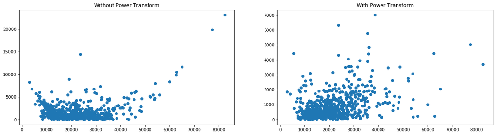

```python
f= plt.figure(figsize=(20,5))

ax=f.add_subplot(121)
plt.scatter('actual', 'abs_diff', data=result1)
ax.set_title('Without Power Transform')

ax=f.add_subplot(122)
plt.scatter('actual', 'abs_diff', data=result2)
ax.set_title('With Power Transform')
```

### Model Design and Evaluation

By iteratively adding layers and experimenting with activation functions, the model architecture with the best performance is a 5 layer simple forward feeding neural network.

- Model 1: baseline model with only 1 input layer and 1 output layer
- Model 2: added a dense layer with 20 neurons and relu activator; performance improvemnet observed
- Model 3: added a dense layer with 10 neurons and relu activator; performance improvement observed
- Model 4: added a dense layer with 10 neurons and sigmoid activator; no performance improvement observed, and therefore rejecting sigmoid activator design
- Model 5: added a dense layer with 5 neurons and relu activator; performance improvement observed
- Model 6: added a dense layer with 5 neurons and relu activator; no performance improvement observed, and therefore stop adding more layers
- Model 7: added a dropout layer with dropout rate 0.1; no performance improvement observed, and therefore rejecting adding dropout layer
- Model 8: re-evaluate number of neurons in Model 5. Change to 16, 8, 4; converaging speed increased, but no performance improvement observed

Model is evaluated using R2 and mean square error.

In below section, code for model 5 is retained.

```python
import tensorflow as tf
import datetime, os
from tensorflow.keras.models import Sequential
from tensorflow.keras.layers import Dense, Dropout
from tensorflow.keras.wrappers.scikit_learn import KerasRegressor
from sklearn.pipeline import Pipeline
from tensorflow.keras import backend as K
```

```python
%load_ext tensorboard
%tensorboard --logdir logs
```

```
The tensorboard extension is already loaded. To reload it, use:
  %reload_ext tensorboard
```

```
Reusing TensorBoard on port 6006 (pid 8013), started 1 day, 16:02:32 ago. (Use '!kill 8013' to kill it.)
```

[interactive chart not shown]

```python
##############################
# baseline model: Model 1 NT #
##############################

# without transforming y NT: not transformed
scaler = MinMaxScaler()
X_trans = scaler.fit_transform(X)
# separate data into train, test, and validate
X_train, X_validate, y_train, y_validate = train_test_split(X_trans, y, test_size=0.20, random_state=99)
X_train, X_test, y_train, y_test = train_test_split(X_train, y_train, test_size=0.20, random_state=99)


def coeff_determination(y_true, y_pred):
    SS_res =  K.sum(K.square( y_true-y_pred ))
    SS_tot = K.sum(K.square( y_true - K.mean(y_true) ) )
    return ( 1 - SS_res/(SS_tot + K.epsilon()) )


def build_model():
    model = Sequential()
    n_input = len(X.columns)
    model.add(Dense(n_input, input_dim=n_input, kernel_initializer='normal', activation='relu'))
    model.add(Dense(1, kernel_initializer='normal'))
    print(model.summary())
    model.compile(loss='mean_squared_error', optimizer='adam', metrics=['mse', coeff_determination])
    return model


def train_model(model):
    logdir = os.path.join("logs", datetime.datetime.now().strftime("%Y%m%d-%H%M%S"))
    tensorboard_callback = tf.keras.callbacks.TensorBoard(logdir, histogram_freq=1, profile_batch=0)
    model.fit(x=X_train, y=y_train,
              batch_size=10, verbose=0,
              epochs=300, validation_data=(X_test, y_test), callbacks=[tensorboard_callback])
    return model

trained_model_1 = train_model(build_model())

# without power transformer
y_pred = trained_model_1.predict(X_validate)
mse = mean_squared_error(y_pred, y_validate)
print(mse)
```

```
Model: "sequential"
_________________________________________________________________
Layer (type)                 Output Shape              Param #
=================================================================
dense (Dense)                (None, 37)                1406
_________________________________________________________________
dense_1 (Dense)              (None, 1)                 38
=================================================================
Total params: 1,444
Trainable params: 1,444
Non-trainable params: 0
_________________________________________________________________
None
8297736.943981611
```

```python
##############
# model 2 NT #
##############

# without transforming y
scaler = MinMaxScaler()
X_trans = scaler.fit_transform(X)
# separate data into train, test, and validate
X_train, X_validate, y_train, y_validate = train_test_split(X_trans, y, test_size=0.20, random_state=99)
X_train, X_test, y_train, y_test = train_test_split(X_train, y_train, test_size=0.20, random_state=99)


def coeff_determination(y_true, y_pred):
    SS_res =  K.sum(K.square( y_true-y_pred ))
    SS_tot = K.sum(K.square( y_true - K.mean(y_true) ) )
    return ( 1 - SS_res/(SS_tot + K.epsilon()) )


def build_model():
    model = Sequential()
    n_input = len(X.columns)
    model.add(Dense(n_input, input_dim=n_input, kernel_initializer='normal', activation='relu')) # model 1
    model.add(Dense(20, activation='relu')) # added in model 2
    model.add(Dense(1, kernel_initializer='normal')) # model 1
    print(model.summary())
    model.compile(loss='mean_squared_error', optimizer='adam', metrics=['mse', coeff_determination])
    return model


def train_model(model):
    logdir = os.path.join("logs", datetime.datetime.now().strftime("%Y%m%d-%H%M%S"))
    tensorboard_callback = tf.keras.callbacks.TensorBoard(logdir, histogram_freq=1, profile_batch=0)
    model.fit(x=X_train, y=y_train,
              batch_size=10, verbose=0,
              epochs=300, validation_data=(X_test, y_test), callbacks=[tensorboard_callback])
    return model

trained_model_2 = train_model(build_model())

# without power transformer
y_pred = trained_model_2.predict(X_validate)
mse = mean_squared_error(y_pred, y_validate)
print(mse)
```

```
Model: "sequential_1"
_________________________________________________________________
Layer (type)                 Output Shape              Param #
=================================================================
dense_2 (Dense)              (None, 37)                1406
_________________________________________________________________
dense_3 (Dense)              (None, 20)                760
_________________________________________________________________
dense_4 (Dense)              (None, 1)                 21
=================================================================
Total params: 2,187
Trainable params: 2,187
Non-trainable params: 0
_________________________________________________________________
None
1743697.1538016067
```

```python
##############
# model 3 NT #
##############

# without transforming y
scaler = MinMaxScaler()
X_trans = scaler.fit_transform(X)
# separate data into train, test, and validate
X_train, X_validate, y_train, y_validate = train_test_split(X_trans, y, test_size=0.20, random_state=99)
X_train, X_test, y_train, y_test = train_test_split(X_train, y_train, test_size=0.20, random_state=99)


def coeff_determination(y_true, y_pred):
    SS_res =  K.sum(K.square( y_true-y_pred ))
    SS_tot = K.sum(K.square( y_true - K.mean(y_true) ) )
    return ( 1 - SS_res/(SS_tot + K.epsilon()) )


def build_model():
    model = Sequential()
    n_input = len(X.columns)
    model.add(Dense(n_input, input_dim=n_input, kernel_initializer='normal', activation='relu')) # model 1
    model.add(Dense(20, activation='relu')) # added in model 2
    model.add(Dense(10, activation='relu')) # added in model 3
    model.add(Dense(1, kernel_initializer='normal')) # model 1
    print(model.summary())
    model.compile(loss='mean_squared_error', optimizer='adam', metrics=['mse', coeff_determination])
    return model


def train_model(model):
    logdir = os.path.join("logs", datetime.datetime.now().strftime("%Y%m%d-%H%M%S"))
    tensorboard_callback = tf.keras.callbacks.TensorBoard(logdir, histogram_freq=1, profile_batch=0)
    model.fit(x=X_train, y=y_train,
              batch_size=10, verbose=0,
              epochs=300, validation_data=(X_test, y_test), callbacks=[tensorboard_callback])
    return model

trained_model_3 = train_model(build_model())

# without power transformer
y_pred = trained_model_3.predict(X_validate)
mse = mean_squared_error(y_pred, y_validate)
print(mse)
```

```
Model: "sequential_2"
_________________________________________________________________
Layer (type)                 Output Shape              Param #
=================================================================
dense_5 (Dense)              (None, 37)                1406
_________________________________________________________________
dense_6 (Dense)              (None, 20)                760
_________________________________________________________________
dense_7 (Dense)              (None, 10)                210
_________________________________________________________________
dense_8 (Dense)              (None, 1)                 11
=================================================================
Total params: 2,387
Trainable params: 2,387
Non-trainable params: 0
_________________________________________________________________
None
1554210.4450980455
```

```python
##############
# model 4 NT #
##############

# without transforming y
scaler = MinMaxScaler()
X_trans = scaler.fit_transform(X)
# separate data into train, test, and validate
X_train, X_validate, y_train, y_validate = train_test_split(X_trans, y, test_size=0.20, random_state=99)
X_train, X_test, y_train, y_test = train_test_split(X_train, y_train, test_size=0.20, random_state=99)


def coeff_determination(y_true, y_pred):
    SS_res =  K.sum(K.square( y_true-y_pred ))
    SS_tot = K.sum(K.square( y_true - K.mean(y_true) ) )
    return ( 1 - SS_res/(SS_tot + K.epsilon()) )


def build_model():
    model = Sequential()
    n_input = len(X.columns)
    model.add(Dense(n_input, input_dim=n_input, kernel_initializer='normal', activation='relu')) # model 1
    model.add(Dense(20, activation='relu')) # added in model 2
    model.add(Dense(10, activation='relu')) # added in model 3
    model.add(Dense(10, activation='sigmoid'))
    model.add(Dense(1, kernel_initializer='normal')) # model 1
    print(model.summary())
    model.compile(loss='mean_squared_error', optimizer='adam', metrics=['mse', coeff_determination])
    return model


def train_model(model):
    logdir = os.path.join("logs", datetime.datetime.now().strftime("%Y%m%d-%H%M%S"))
    tensorboard_callback = tf.keras.callbacks.TensorBoard(logdir, histogram_freq=1, profile_batch=0)
    model.fit(x=X_train, y=y_train,
              batch_size=10, verbose=0,
              epochs=300, validation_data=(X_test, y_test), callbacks=[tensorboard_callback])
    return model

trained_model_4 = train_model(build_model())

# without power transformer
y_pred = trained_model_4.predict(X_validate)
mse = mean_squared_error(y_pred, y_validate)
print(mse)
```

```
Model: "sequential_3"
_________________________________________________________________
Layer (type)                 Output Shape              Param #
=================================================================
dense_9 (Dense)              (None, 37)                1406
_________________________________________________________________
dense_10 (Dense)             (None, 20)                760
_________________________________________________________________
dense_11 (Dense)             (None, 10)                210
_________________________________________________________________
dense_12 (Dense)             (None, 10)                110
_________________________________________________________________
dense_13 (Dense)             (None, 1)                 11
=================================================================
Total params: 2,497
Trainable params: 2,497
Non-trainable params: 0
_________________________________________________________________
None
563719201.4390745
```

```python
##############
# model 5 NT #
##############

# without transforming y
scaler = MinMaxScaler()
X_trans = scaler.fit_transform(X)
# separate data into train, test, and validate
X_train, X_validate, y_train, y_validate = train_test_split(X_trans, y, test_size=0.20, random_state=99)
X_train, X_test, y_train, y_test = train_test_split(X_train, y_train, test_size=0.20, random_state=99)


def coeff_determination(y_true, y_pred):
    SS_res =  K.sum(K.square( y_true-y_pred ))
    SS_tot = K.sum(K.square( y_true - K.mean(y_true) ) )
    return ( 1 - SS_res/(SS_tot + K.epsilon()) )


def build_model():
    model = Sequential()
    n_input = len(X.columns)
    model.add(Dense(n_input, input_dim=n_input, kernel_initializer='normal', activation='relu')) # model 1
    model.add(Dense(20, activation='relu')) # added in model 2
    model.add(Dense(10, activation='relu')) # added in model 3
    # model.add(Dense(10, activation='sigmoid')) # added in model 4 rejected due to bad performance
    model.add(Dense(5, activation='relu'))
    model.add(Dense(1, kernel_initializer='normal')) # model 1
    print(model.summary())
    model.compile(loss='mean_squared_error', optimizer='adam', metrics=['mse', coeff_determination])
    return model


def train_model(model):
    logdir = os.path.join("logs", datetime.datetime.now().strftime("%Y%m%d-%H%M%S"))
    tensorboard_callback = tf.keras.callbacks.TensorBoard(logdir, histogram_freq=1, profile_batch=0)
    model.fit(x=X_train, y=y_train,
              batch_size=10, verbose=0,
              epochs=300, validation_data=(X_test, y_test), callbacks=[tensorboard_callback])
    return model

trained_model_5 = train_model(build_model())

# without power transformer
y_pred = trained_model_5.predict(X_validate)
mse = mean_squared_error(y_pred, y_validate)
print(mse)
```

```
Model: "sequential_9"
_________________________________________________________________
Layer (type)                 Output Shape              Param #
=================================================================
dense_40 (Dense)             (None, 37)                1406
_________________________________________________________________
dense_41 (Dense)             (None, 20)                760
_________________________________________________________________
dense_42 (Dense)             (None, 10)                210
_________________________________________________________________
dense_43 (Dense)             (None, 5)                 55
_________________________________________________________________
dense_44 (Dense)             (None, 1)                 6
=================================================================
Total params: 2,437
Trainable params: 2,437
Non-trainable params: 0
_________________________________________________________________
None
1240195.596900131
```

```python
np.sqrt(1247297.0103068838)
```

```
1116.8245208209228
```

```python
result1 = pd.DataFrame({'predict': y_pred.flatten().tolist(), 'actual': y_validate})
result1['abs_diff'] = abs(result1.predict - result1.actual)
result1.sort_values(by='abs_diff', ascending=False, inplace=True)
```

```python
##############
# model 7 NT #
##############

# without transforming y
scaler = MinMaxScaler()
X_trans = scaler.fit_transform(X)
# separate data into train, test, and validate
X_train, X_validate, y_train, y_validate = train_test_split(X_trans, y, test_size=0.20, random_state=99)
X_train, X_test, y_train, y_test = train_test_split(X_train, y_train, test_size=0.20, random_state=99)


def coeff_determination(y_true, y_pred):
    SS_res =  K.sum(K.square( y_true-y_pred ))
    SS_tot = K.sum(K.square( y_true - K.mean(y_true) ) )
    return ( 1 - SS_res/(SS_tot + K.epsilon()) )


def build_model():
    model = Sequential()
    n_input = len(X.columns)
    model.add(Dense(n_input, input_dim=n_input, kernel_initializer='normal', activation='relu')) # model 1
    model.add(Dense(20, activation='relu')) # added in model 2
    model.add(Dense(10, activation='relu')) # added in model 3
    # model.add(Dense(10, activation='sigmoid')) # added in model 4 rejected due to bad performance
    model.add(Dense(5, activation='relu')) # added in model 5
    # model.add(Dense(5, activation='relu')) # added in model 6; rejected due to no substantial improvement
    model.add(Dropout(0.1))
    model.add(Dense(1, kernel_initializer='normal')) # model 1
    print(model.summary())
    model.compile(loss='mean_squared_error', optimizer='adam', metrics=['mse', coeff_determination])
    return model


def train_model(model):
    logdir = os.path.join("logs", datetime.datetime.now().strftime("%Y%m%d-%H%M%S"))
    tensorboard_callback = tf.keras.callbacks.TensorBoard(logdir, histogram_freq=1, profile_batch=0)
    model.fit(x=X_train, y=y_train,
              batch_size=10, verbose=0,
              epochs=300, validation_data=(X_test, y_test), callbacks=[tensorboard_callback])
    return model

trained_model_7 = train_model(build_model())

# without power transformer
y_pred = trained_model_7.predict(X_validate)
mse = mean_squared_error(y_pred, y_validate)
print(mse)
```

```
Model: "sequential_7"
_________________________________________________________________
Layer (type)                 Output Shape              Param #
=================================================================
dense_30 (Dense)             (None, 37)                1406
_________________________________________________________________
dense_31 (Dense)             (None, 20)                760
_________________________________________________________________
dense_32 (Dense)             (None, 10)                210
_________________________________________________________________
dense_33 (Dense)             (None, 5)                 55
_________________________________________________________________
dropout (Dropout)            (None, 5)                 0
_________________________________________________________________
dense_34 (Dense)             (None, 1)                 6
=================================================================
Total params: 2,437
Trainable params: 2,437
Non-trainable params: 0
_________________________________________________________________
None
2317346.7992870025
```

```python
##############
# model 8 NT #
##############

# without transforming y
scaler = MinMaxScaler()
X_trans = scaler.fit_transform(X)
# separate data into train, test, and validate
X_train, X_validate, y_train, y_validate = train_test_split(X_trans, y, test_size=0.20, random_state=99)
X_train, X_test, y_train, y_test = train_test_split(X_train, y_train, test_size=0.20, random_state=99)


def coeff_determination(y_true, y_pred):
    SS_res =  K.sum(K.square( y_true-y_pred ))
    SS_tot = K.sum(K.square( y_true - K.mean(y_true) ) )
    return ( 1 - SS_res/(SS_tot + K.epsilon()) )


def build_model():
    model = Sequential()
    n_input = len(X.columns)
    model.add(Dense(n_input, input_dim=n_input, kernel_initializer='normal', activation='relu')) # model 1
    model.add(Dense(16, activation='relu')) # number of neuron changed in model 8
    model.add(Dense(8, activation='relu')) # number of neuron changed in model 8
    # model.add(Dense(10, activation='sigmoid')) # added in model 4 rejected due to bad performance
    model.add(Dense(4, activation='relu')) # number of neuron changed in model 8
    # model.add(Dense(5, activation='relu')) # added in model 6; rejected due to no substantial improvement
    # model.add(Dropout(0.1)) # rejected due to bad performance
    model.add(Dense(1, kernel_initializer='normal')) # model 1
    print(model.summary())
    model.compile(loss='mean_squared_error', optimizer='adam', metrics=['mse', coeff_determination])
    return model


def train_model(model):
    logdir = os.path.join("logs", datetime.datetime.now().strftime("%Y%m%d-%H%M%S"))
    tensorboard_callback = tf.keras.callbacks.TensorBoard(logdir, histogram_freq=1, profile_batch=0)
    model.fit(x=X_train, y=y_train,
              batch_size=10, verbose=0,
              epochs=300, validation_data=(X_test, y_test), callbacks=[tensorboard_callback])
    return model

trained_model_8 = train_model(build_model())

# without power transformer
y_pred = trained_model_8.predict(X_validate)
mse = mean_squared_error(y_pred, y_validate)
print(mse)
```

```
Model: "sequential_8"
_________________________________________________________________
Layer (type)                 Output Shape              Param #
=================================================================
dense_35 (Dense)             (None, 37)                1406
_________________________________________________________________
dense_36 (Dense)             (None, 16)                608
_________________________________________________________________
dense_37 (Dense)             (None, 8)                 136
_________________________________________________________________
dense_38 (Dense)             (None, 4)                 36
_________________________________________________________________
dense_39 (Dense)             (None, 1)                 5
=================================================================
Total params: 2,191
Trainable params: 2,191
Non-trainable params: 0
_________________________________________________________________
None
1575215.2558385958
```

### Model 5 (No Power Transformation) Cross Validation

```python
##############
# model 5 NT #
##############
# cross validation - r2

def build_model():
    model = Sequential()
    n_input = len(X.columns)
    model.add(Dense(n_input, input_dim=n_input, kernel_initializer='normal', activation='relu')) # model 1
    model.add(Dense(20, activation='relu')) # added in model 2
    model.add(Dense(10, activation='relu')) # added in model 3
    # model.add(Dense(10, activation='sigmoid')) # added in model 4 rejected due to bad performance
    model.add(Dense(5, activation='relu')) # added in model 5
    # model.add(Dense(5, activation='relu')) # added in model 6 rejected due to worse performance than model 5

    model.add(Dense(1, kernel_initializer='normal')) # model 1
    # print(model.summary())
    model.compile(loss='mean_squared_error', optimizer='adam', metrics=['mse', coeff_determination])
    return model

estimators = []
estimators.append(('minmaxscale', MinMaxScaler()))
estimators.append(('mlp', KerasRegressor(build_fn=build_model, epochs=500, batch_size=10, verbose=0)))
pipeline = Pipeline(estimators)
results = cross_val_score(pipeline, X, y, cv=5, scoring='r2')
print("Standardized: %.2f (%.2f) coefficient of regression" % (results.mean(), results.std()))
```

```
Standardized: 0.99 (0.00) coefficient of regression
```

```python
##############
# model 5 NT #
##############
# cross validation - mse
estimators = []
estimators.append(('minmaxscale', MinMaxScaler()))
estimators.append(('mlp', KerasRegressor(build_fn=build_model, epochs=500, batch_size=10, verbose=0)))
pipeline = Pipeline(estimators)
results = cross_val_score(pipeline, X, y, cv=5)
print("Standardized: %.2f (%.2f) MSE" % (results.mean(), results.std()))
```

```
Standardized: -756317.06 (190888.13) MSE
```

```python
np.sqrt(756317.06)
```

```
869.6649124806635
```

### Model 5 (With Power Transformation) Cross Validation

```python
#############
# model 5 T #
#############

scaler = MinMaxScaler()
X_trans = scaler.fit_transform(X)
pt = PowerTransformer()
y_trans = pt.fit_transform(y.values.reshape(-1,1))
# separate data into train, test, and validate
X_train, X_validate, y_train, y_validate = train_test_split(X_trans, y_trans, test_size=0.20, random_state=99)
X_train, X_test, y_train, y_test = train_test_split(X_train, y_train, test_size=0.20, random_state=99)


def coeff_determination(y_true, y_pred):
    SS_res =  K.sum(K.square( y_true-y_pred ))
    SS_tot = K.sum(K.square( y_true - K.mean(y_true) ) )
    return ( 1 - SS_res/(SS_tot + K.epsilon()) )


def build_model():
    model = Sequential()
    n_input = len(X.columns)
    model.add(Dense(n_input, input_dim=n_input, kernel_initializer='normal', activation='relu')) # model 1
    model.add(Dense(20, activation='relu')) # added in model 2
    model.add(Dense(10, activation='relu')) # added in model 3
    # model.add(Dense(10, activation='sigmoid')) # added in model 4 rejected due to bad performance
    model.add(Dense(5, activation='relu')) # added in model 5
    # model.add(Dense(5, activation='relu')) # added in model 6 rejected due to worse performance than model 5

    model.add(Dense(1, kernel_initializer='normal')) # model 1
    # print(model.summary())
    model.compile(loss='mean_squared_error', optimizer='adam', metrics=['mse', coeff_determination])
    return model


def train_model(model):
    logdir = os.path.join("logs", datetime.datetime.now().strftime("%Y%m%d-%H%M%S"))
    tensorboard_callback = tf.keras.callbacks.TensorBoard(logdir, histogram_freq=1, profile_batch=0)
    model.fit(x=X_train, y=y_train,
              batch_size=10, verbose=0,
              epochs=300, validation_data=(X_test, y_test), callbacks=[tensorboard_callback])
    return model

trained_model_t = train_model(build_model())
```

```python
# inverse transform prediction and get MSE
y_pred = trained_model_t.predict(X_validate)
y_pred = pt.inverse_transform(y_pred.reshape(-1,1)).flatten().tolist()
y_validate = pt.inverse_transform(y_validate).flatten().tolist()
mse = mean_squared_error(y_pred, y_validate)
print(mse)
np.sqrt(mse)
```

```
560490.1695971142
```

```
748.6589140570719
```

```python
result2 = pd.DataFrame({'predict': y_pred, 'actual': y_validate})
result2['abs_diff'] = abs(result2.predict - result2.actual)
result2.sort_values(by='abs_diff', ascending=False, inplace=True)
```

```python
#############
# model 5 T #
#############
# cross validation - r2
estimators = []
estimators.append(('minmaxscale', MinMaxScaler()))
estimators.append(('powertransform', PowerTransformer()))
estimators.append(('mlp', KerasRegressor(build_fn=build_model, epochs=500, batch_size=10, verbose=0)))
pipeline = Pipeline(estimators)
results = cross_val_score(pipeline, X, y, cv=5, scoring='r2')
print("Standardized: %.2f (%.2f) coefficient of regression" % (results.mean(), results.std()))
```

```
Standardized: 0.99 (0.00) coefficient of regression
```

```python
def build_model():
    model = Sequential()
    n_input = len(X.columns)
    model.add(Dense(n_input, input_dim=n_input, kernel_initializer='normal', activation='relu')) # model 1
    model.add(Dense(20, activation='relu')) # added in model 2
    model.add(Dense(10, activation='relu')) # added in model 3
    # model.add(Dense(10, activation='sigmoid')) # added in model 4 rejected due to bad performance
    model.add(Dense(5, activation='relu')) # added in model 5
    # model.add(Dense(5, activation='relu')) # added in model 6 rejected due to worse performance than model 5

    model.add(Dense(1, kernel_initializer='normal')) # model 1
    # print(model.summary())
    model.compile(loss='mean_squared_error', optimizer='adam', metrics=['mse', coeff_determination])
    return model
# cross validation - mse
estimators = []
estimators.append(('minmaxscale', MinMaxScaler()))
estimators.append(('powertransform', PowerTransformer()))
estimators.append(('mlp', KerasRegressor(build_fn=build_model, epochs=500, batch_size=10, verbose=0)))
pipeline = Pipeline(estimators)
results = cross_val_score(pipeline, X, y, cv=5)
print("Standardized: %.2f (%.2f) MSE" % (results.mean(), results.std()))
```

```
Standardized: 0.43 (1.68) MSE
```

Sklearn's MSE cannot be directly used for NN evaluation after power transform

### Compare Abosolute Error Distribution by Target Variable (No Power Transform vs Power Transform)

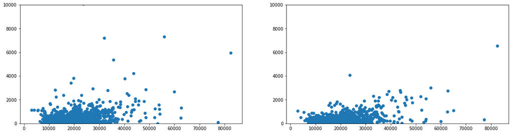

```python
fig = plt.figure(figsize=(20,5))
ax1 = fig.add_subplot(1, 2, 1)
ax2 = fig.add_subplot(1, 2, 2, sharex=ax1)
ax1.set_ylim(0,10000)
ax2.set_ylim(0,10000)
ax1.scatter('actual', 'abs_diff', data=result1)
ax2.scatter('actual', 'abs_diff', data=result2)
```